# 20211_M2.855_PEC3_Solución

# 2. Implementación de un caso práctico (5 puntos)

Ahora que ya entendemos cómo funcionan algunos modelos, vamos a aplicarlos a un caso práctico. La primera mitad de la práctica se ha realizado utilizando una variable objetivo categórica, para esta segunda mitad emplearemos una variable objetivo numérica. Es decir, trabajaremos con un problema de regresión, no de clasificación.

Utilizaremos un conjunto de datos público de precios de viviendas en Taiwán con el objetivo de encontrar las mejores ofertas del mercado. La descripción completa del conjunto de datos la podemos encontrar en el siguiente enlace: https://archive.ics.uci.edu/ml/datasets/Real+estate+valuation+data+set

Comencemos cargando los datos en un DataFrame de pandas:

```python
dataset = pd.read_excel('Real estate valuation data set.xlsx', engine='openpyxl')

dataset.head()
```

|  | No | X1 transaction date | X2 house age | X3 distance to the nearest MRT station | X4 number of convenience stores | X5 latitude | X6 longitude | Y house price of unit area |
| --- | --- | --- | --- | --- | --- | --- | --- | --- |
| 0 | 1 | 2012.916667 | 32.0 | 84.87882 | 10 | 24.98298 | 121.54024 | 37.9 |
| 1 | 2 | 2012.916667 | 19.5 | 306.59470 | 9 | 24.98034 | 121.53951 | 42.2 |
| 2 | 3 | 2013.583333 | 13.3 | 561.98450 | 5 | 24.98746 | 121.54391 | 47.3 |
| 3 | 4 | 2013.500000 | 13.3 | 561.98450 | 5 | 24.98746 | 121.54391 | 54.8 |
| 4 | 5 | 2012.833333 | 5.0 | 390.56840 | 5 | 24.97937 | 121.54245 | 43.1 |

La primera columna ("*No*") es el identificador numérico de la muestra. Las columnes "*Xn ...*" son los diferentes atributos descriptivos. Finalmente, la columna "*Y ...*" es el valor objetivo o precio de la vivienda.

Extraemos del *DataFrame* la variable objetivo y los atributos descriptivos que utilizaremos posteriormente en el modelo predictivo:

```python
X = dataset[[
    'X2 house age',
    'X3 distance to the nearest MRT station',
    'X4 number of convenience stores',
    'X5 latitude',
    'X6 longitude'
]]

y = dataset['Y house price of unit area']
```

### 2.1. Análisis descriptivo

Cuando se nos proporciona un dataset, antes de comenzar a hacer nada, es muy importante hacer un análisis exploratorio para conocer los datos con los que trabajaremos.

**Implementación:** analizar gráficamente la distribución de todas las variables (features y target). Recuerda que las variables categóricass se representan con gráficas de barras, mientras que las numéricas se representan con histogramas.

**Solución:**

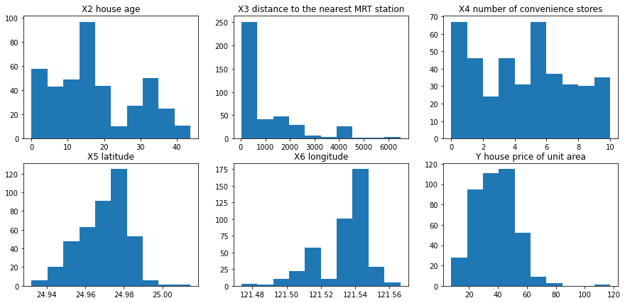

```python
#############################################
# SOLUCIÓN                                  #
#############################################

fig, ax = plt.subplots(2, 3, figsize = (15, 7))

ax[0][0].hist(X['X2 house age'])
ax[0][1].hist(X['X3 distance to the nearest MRT station'])
ax[0][2].hist(X['X4 number of convenience stores'])
ax[1][0].hist(X['X5 latitude'])
ax[1][1].hist(X['X6 longitude'])
ax[1][2].hist(y)

ax[0][0].set_title('X2 house age')
ax[0][1].set_title('X3 distance to the nearest MRT station')
ax[0][2].set_title('X4 number of convenience stores')
ax[1][0].set_title('X5 latitude')
ax[1][1].set_title('X6 longitude')
ax[1][2].set_title('Y house price of unit area')

plt.show()
```

### 2.2. Preprocesamiento de los datos

Una vez hecho un primer análisis, se trata de "limpiar" el dataset (las features) y adaptarlo a nuestras necesidades (en este caso, predecir el precio de una vivienda).

**Implementación:** comprueba si hay valores nulos. En caso de haberlos, elimina las filas correspondientes.

**Solución:**

```python
#############################################
# SOLUCIÓN                                  #
#############################################

X.isnull().sum().sum()
```

```
0
```

El siguiente paso sería estudiar la correlación entre todas las variables descriptivas (features) numéricas. Esto se hace para asegurarse de que no hay dos variables muy relacionadas entre sí, ya que en tal caso sería conveniente seleccionar una de las dos o combinarlas en una nueva para reducir dimensionalidad.

**Implementación:** muestra la correlación entre todas las features numéricas. Si hay dos con una correlación superior al 90%, elimina una de ellas. Puedes utilizar heatmap, de seaborn, para verlas en un mapa de colores.

**Solución:**

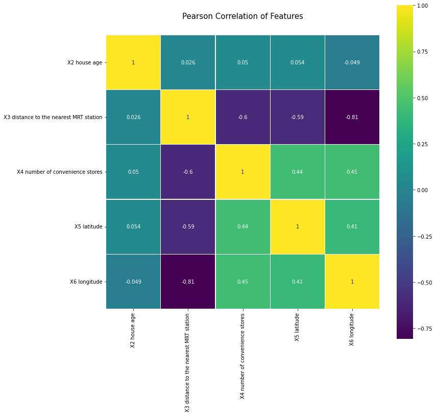

```python
#############################################
# SOLUCIÓN                                  #
#############################################

colormap = plt.cm.viridis
plt.figure(figsize=(12,12))
plt.title('Pearson Correlation of Features', y=1.05, size=15)
sns.heatmap(X.astype(float).corr(),
            linewidths=0.1, vmax=1.0, square=True,
            cmap=colormap, linecolor='white', annot=True)
```

Ya tenemos las variables finales con las que trabajaremos. Vamos a observar ahora cuál es la relación de cada una de ellas con el target.

**Implementación:** realiza varios scatterplots cruzando los diferentes atributos descriptivos con la variable target. Se ha de realizar un scatterplot por atributo.

**Solución:**

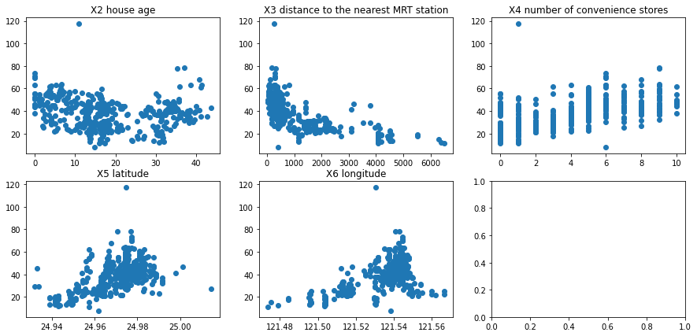

```python
#############################################
# SOLUCIÓN                                  #
#############################################

fig, ax = plt.subplots(2, 3, figsize = (15, 7))

ax[0][0].scatter(X['X2 house age'], y)
ax[0][1].scatter(X['X3 distance to the nearest MRT station'], y)
ax[0][2].scatter(X['X4 number of convenience stores'], y)
ax[1][0].scatter(X['X5 latitude'], y)
ax[1][1].scatter(X['X6 longitude'], y)

ax[0][0].set_title('X2 house age')
ax[0][1].set_title('X3 distance to the nearest MRT station')
ax[0][2].set_title('X4 number of convenience stores')
ax[1][0].set_title('X5 latitude')
ax[1][1].set_title('X6 longitude')

plt.show()
```

**Análisis:** ¿qué atributos tienen correlación positiva? ¿Cuáles negativa? ¿Cuáles no tienen ninguna correlación? Analiza cada uno de los gráficos. ¿Tiene sentido que la relación de cada atributo con el target sea la encontrada?

**Solución:** - House age: hay un primer grupo de casas que cuanto más nuevas son más caras, después pierden valor con los años, y finalmente parece que si sobrepasan un umbral (viviendas antiguas de más de 30 años) vuelven a recuperar valor. - Distance to the nearest MRT station: hay una correlación negativa, lo cuál tiene sentido, ya que cuanto más cerca esté la vivienda de la estación, más cara es. - Number of conveniece stores: correlación positiva, cuantas más tiendas tenga cerca, más cara será la vivienda. - Latitud y longitud: no tienen correlación, es una nube de puntos, esto se debe a que las viviendas céntricas o en barrios caros se agrupan por zonas y depende en cada ciudad de unas coordenadas u otras.

### 2.3. Entrenamiento de un modelo

Ahora que ya tenemos el dataset limpio y hemos hecho un análisis de las diferentes variables, podemos proceder a entrenar un modelo para predecir el precio de una vivienda. Probaremos con 2 modelos diferentes e interpretaremos sus resultados. Para comenzar, separemos el dataset en train y test.

**Implementación:** divide el *dataset* en dos subconjuntos, *train* (80% de los datos) y *test* (20% restante). Nombraremos los conjuntos: X_train, X_test, y_train e y_test. Utilizaremos la opción random_state=24. Puedes servirte de la implementación *train_test_split* de *sklearn*.

**Solución:**

```python
#############################################
# SOLUCIÓN                                  #
#############################################

X_train, X_test, y_train, y_test = train_test_split(X, y, test_size=0.2, random_state=24)
```

**Implementación:** utiliza un árbol de decisión simple con max_depth=5 para modelar el dataset sobre el conjunto de train. Dibuja el árbol de decisión. Si te queda muy grande, dibuja un árbol entrenado con menor profundidad para que puedas apreciarlo mejor. Utiliza alguna medida de error (puedes escoger la que quieras: MAE, RMSE, ...) para estimar cómo de bien lo ha hecho el modelo prediciedo en train y en test. También servirá para poder comparar a posteriori con otro modelo. Para dibujar el árbol puedes guiarte con este enlace: https://towardsdatascience.com/visualizing-decision-trees-with-python-scikit-learn-graphviz-matplotlib-1c50b4aa68dc. Towardsdatascience es un blog que te deja leer unos cuantos artículos gratuitamente y despues te pide subscripción. Si fuera el caso y ya hubieras llegado al límite, puedes abrir el enlace en una pestaña de navegación privada.

**Solución:**

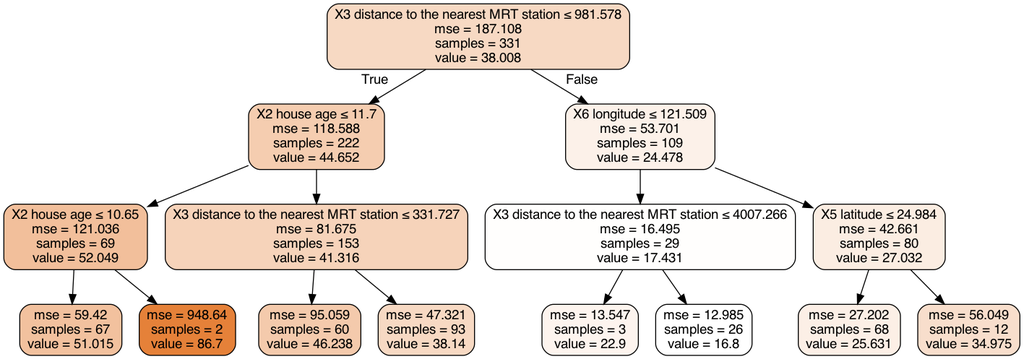

```python
#############################################
# SOLUCIÓN                                  #
#############################################

def plot_decision_tree(clf, fn):
    cn=['0', '1', '2']

    dot_data = StringIO()
    export_graphviz(clf,
                    feature_names = fn,
                    class_names=cn,
                    out_file=dot_data,
                    filled=True, rounded=True,
                    special_characters=True)
    graph = pydotplus.graph_from_dot_data(dot_data.getvalue())
    return Image(graph.create_png())

fn = list(X.columns)
dt = DecisionTreeRegressor(max_depth = 5)
dt_plot = DecisionTreeRegressor(max_depth = 3)
dt.fit(X_train, y_train)
dt_plot.fit(X_train, y_train)
plot_decision_tree(dt_plot, fn)
```

```python
#############################################
# SOLUCIÓN                                  #
#############################################

def rmse(y_true, y_pred):
    return np.sqrt(((y_true - y_pred) ** 2).sum() / y_true.size)

preds_train = dt.predict(X_train)
print('RMSE train: ', rmse(y_train, preds_train))

preds_test = dt.predict(X_test)
print('RMSE test: ', rmse(y_test, preds_test))
```

```
RMSE train:  5.087878732177842
RMSE test:  13.293236829792974
```

**Análisis:** interpreta el árbol de decisión, ¿qué variables son las que han tenido más peso? ¿Has obtenido una buena precisión evaluando en test? ¿Se ha producido overfitting?

**Solución:** el atributo más importante es la distancia a la estación de tren, es la que más discrimina seguida de la edad de la casa y la localización (latitud-longitud). Los resultados no són muy buenos, ya que se produce mucho overfitting. En train tenemos un RMSE mucho menor que en test.

**Implementación:** utiliza Random Forest o Gradient Boosting para modelar el dataset. Esta vez vamos a optimizar el modelo para obtener los mejores resultados posibles. Tal y como hemos visto anteriormente, recuerda seguir los siguientes pasos: - Utilizar el dataset de train para encontrar los mejores hiperparámetros haciendo cross-validation. - Entrenar el modelo con train, predecir con train y test y calcular el error (MAE, RMSE, ...)

**Solución:**

```python
#############################################
# SOLUCIÓN                                  #
#############################################

rf = RandomForestRegressor(random_state=24)

param_grid = {"n_estimators": [10, 20, 50], "max_depth": range(7, 14)}

grid_search = GridSearchCV(rf, param_grid=param_grid, cv=4)
grid_search.fit(X_train, y_train)

means = grid_search.cv_results_["mean_test_score"]
stds = grid_search.cv_results_["std_test_score"]
params = grid_search.cv_results_['params']

for mean, std, pms in zip(means, stds, params):
    print("Precisión media: {:.2f} +/- {:.2f} con los parámetros {}".format(mean*100, std*100, pms))
```

```
Precisión media: 67.91 +/- 6.68 con los parámetros {'max_depth': 7, 'n_estimators': 10}
Precisión media: 67.99 +/- 7.23 con los parámetros {'max_depth': 7, 'n_estimators': 20}
Precisión media: 67.62 +/- 6.89 con los parámetros {'max_depth': 7, 'n_estimators': 50}
Precisión media: 68.06 +/- 6.49 con los parámetros {'max_depth': 8, 'n_estimators': 10}
Precisión media: 68.27 +/- 6.83 con los parámetros {'max_depth': 8, 'n_estimators': 20}
Precisión media: 67.78 +/- 6.61 con los parámetros {'max_depth': 8, 'n_estimators': 50}
Precisión media: 67.24 +/- 6.81 con los parámetros {'max_depth': 9, 'n_estimators': 10}
Precisión media: 67.88 +/- 6.96 con los parámetros {'max_depth': 9, 'n_estimators': 20}
Precisión media: 67.79 +/- 6.91 con los parámetros {'max_depth': 9, 'n_estimators': 50}
Precisión media: 67.70 +/- 6.64 con los parámetros {'max_depth': 10, 'n_estimators': 10}
Precisión media: 68.15 +/- 6.85 con los parámetros {'max_depth': 10, 'n_estimators': 20}
Precisión media: 67.91 +/- 6.80 con los parámetros {'max_depth': 10, 'n_estimators': 50}
Precisión media: 68.19 +/- 6.28 con los parámetros {'max_depth': 11, 'n_estimators': 10}
Precisión media: 68.36 +/- 6.77 con los parámetros {'max_depth': 11, 'n_estimators': 20}
Precisión media: 67.97 +/- 6.46 con los parámetros {'max_depth': 11, 'n_estimators': 50}
Precisión media: 67.06 +/- 6.36 con los parámetros {'max_depth': 12, 'n_estimators': 10}
Precisión media: 67.97 +/- 6.73 con los parámetros {'max_depth': 12, 'n_estimators': 20}
Precisión media: 67.68 +/- 6.74 con los parámetros {'max_depth': 12, 'n_estimators': 50}
Precisión media: 67.54 +/- 6.68 con los parámetros {'max_depth': 13, 'n_estimators': 10}
Precisión media: 68.33 +/- 6.77 con los parámetros {'max_depth': 13, 'n_estimators': 20}
Precisión media: 67.72 +/- 6.67 con los parámetros {'max_depth': 13, 'n_estimators': 50}
```

```python
#############################################
# SOLUCIÓN                                  #
#############################################

param1 = [x['n_estimators'] for x in params]
param2 = [x['max_depth'] for x in params]

precisions = pd.DataFrame(zip(param1, param2, means), columns=['n_estimators', 'max_depth', 'means'])
precisions = precisions.pivot('n_estimators', 'max_depth', 'means')
sns.heatmap(precisions)
```

[output not shown]

[figure not shown]

```python
#############################################
# SOLUCIÓN                                  #
#############################################

rf = RandomForestRegressor(n_estimators=20, max_depth=8, random_state=24)
rf.fit(X_train.values, y_train)

preds_train = rf.predict(X_train.values)
print('RMSE train: ', rmse(y_train, preds_train))

preds_test = rf.predict(X_test.values)
print('RMSE test: ', rmse(y_test, preds_test))
```

[output not shown]

Un Random Forest / Gradient Boosting no es tan fácil de interpretar como un simple Decision Tree. No podemos dibujar un árbol porque son combinaciones de muchos árboles, pero sí que podemos saber cuáles han sido las variables más decisivas a la hora de generar el modelo. Para saberlo, no podremos hacerlo mirando cómo se divide el árbol, sino que se lo tendremos que consultar al modelo através de la "feature importance" de éste.

**Implementación:** muestra cada variable del modelo aprendido junto con su feature importance.

**Solución:**

```python
#############################################
# SOLUCIÓN                                   #
#############################################

feature_importance = pd.DataFrame({'feature': list(X.columns), 'importance': list(rf.feature_importances_)})
feature_importance.sort_values('importance', ascending=False)
```

|  | feature | importance |
| --- | --- | --- |
| 1 | X3 distance to the nearest MRT station | 0.604792 |
| 0 | X2 house age | 0.199029 |
| 3 | X5 latitude | 0.096752 |
| 4 | X6 longitude | 0.079096 |
| 2 | X4 number of convenience stores | 0.020331 |

**Análisis:** interpreta el clasificador, ¿cuáles son las variables que han tenido más peso? ¿Has obtenido una buena precisión evaluando en test? ¿Se ha producido overfitting?

**Solución:** igual que con un árbol de decisión simple, el atributo más importante es la distancia a la estación de tren, es la que más discrimina seguida de la edad de la casa y la localización (latitud-longitud). De todas maneras, en comparación con la distància a la estación de tren, el resto de variables tienen muy poco peso. A pesar de que se produce overfitting, es menos pronunciado y los resultados son mmejores que con un árbol de decisión simple.

### 2.4. Predicción de casos nuevos

Hasta ahora hemos entrenado un modelo y hemos evaluado en test para hacernos una idea de la precisión de nuestro modelo con datos reales. Ahora vamos a utilizarlo.

**Implementación:** - Caso 1: queremos comprar una vivienda que está situada a 1km de la estación de tren, concretamente sus coordenadas son: 24.87745, 121.31683. La vivienda tiene 3 tiendas cerca y se construyó hace 15 años. Se vende por 24500€/m2 y queremos saber si está por encima o por debajo del precio de mercado. - Caso 2: somos una empresa que se dedica a hacer negocio comprando pisos baratos, arreglándolos y volviéndolos a vender más caros. Queremos saber qué viviendas del conjunto de datos se venden por debajo de su precio de mercado ("chollos") para poder comprarlas y revenderlas en un futuro.

**Solución:**

```python
#############################################
# SOLUCIÓN                                  #
#############################################

print('Caso 1. Precio de mercado: ', rf.predict([[15, 1000, 3, 24.87745, 121.31683]]))
```

```
Caso 1. Precio de mercado:  [21.89875]
```

```python
#############################################
# SOLUCIÓN                                  #
#############################################

print('Caso 2. Los "chollos" son, de mayor a menor: ')

predictions = rf.predict(X_test.values)
price_diff = predictions - y_test

X_test['real_price'] = y_test
X_test['market_value_price'] = predictions

X_test.iloc[np.argsort(-price_diff)].head()
```

```
Caso 2. Los "chollos" son, de mayor a menor:
```

|  | X2 house age | X3 distance to the nearest MRT station | X4 number of convenience stores | X5 latitude | X6 longitude | real_price | market_value_price |
| --- | --- | --- | --- | --- | --- | --- | --- |
| 31 | 29.6 | 769.40340 | 7 | 24.98281 | 121.53408 | 25.0 | 43.583974 |
| 158 | 11.6 | 390.56840 | 5 | 24.97937 | 121.54245 | 39.4 | 57.750469 |
| 327 | 3.5 | 757.33770 | 3 | 24.97538 | 121.54971 | 36.7 | 47.964521 |
| 136 | 11.4 | 390.56840 | 5 | 24.97937 | 121.54245 | 46.8 | 57.750469 |
| 0 | 32.0 | 84.87882 | 10 | 24.98298 | 121.54024 | 37.9 | 47.192459 |